# P6_Chadeau_notebook4_analyse_univ_sex_age

```python
from IPython.core.display import display, HTML
f = open("P6_Chadeau_notebook4_sommaire.html", "r", encoding="utf-8")
display(HTML(f.read()))
```

TOP  
Importation des librairies et fichiers  
Déclaration des fonctions  
Importation dataframe  
La mission

- Analyses univariées

- Variable qualitative 'sex'

- Variable qualititative 'age'

- Répartition du CA entre clients

- Top 10 des clients qui ont passé le plus de commandes

- Distribution des âges des clients dans les ventes sans les 4 outliers

- Distribution du genre client dans les ventes sans les 4 outliers

- Les plus gros acheteurs par catégorie

- Répartition du CA entre clients sans les outliers

- Analyse des 4 clients professionnels

# Projet 6 -Analysez les ventes d'une librairie avec R ou Python

[figure not shown]

## NOTEBOOK 4 - ANALYSES UNIVARIEES (suite)

### Importation des librairies et fichiers

```python
import pandas as pd
import numpy as np
import re
import matplotlib.pyplot as plt
import seaborn as sns
import datetime
from statsmodels.tsa.stattools import adfuller

#Permet d'afficher toutes les lignes d'une liste
pd.set_option("max_rows", None)

#Permet l'affichage de tous les résultats d'une cellule (pas seulement le dernier)
from IPython.core.interactiveshell import InteractiveShell
InteractiveShell.ast_node_interactivity = "all"

#Permet de définir des paramètres d'affichage pour l'ensemble des graphiques
from pylab import rcParams
rcParams['figure.figsize'] = 15, 5
```

### Déclaration des fonctions

```python
class graphic():
    def lorenz_gini(data,title,medial,mediane):

        n = len(data)
        #Tri des individus dans l'ordre croissant des valeurs de la variable + calcul de la somme cumulée
        #et division par la somme des observations afin que le haut de la courbe soit à 1
        lorenz = np.cumsum(np.sort(data)) / data.sum()
        lorenz = np.append([0],lorenz)

        fig = plt.figure(figsize=(6, 6))
        memo=plt.axes().axis('equal')
        xaxis=np.linspace(0,1,len(lorenz))

        plt.plot(xaxis,lorenz,'blue', label='Courbe de Lorenz')
        memo=plt.axis([0, 1, 0, 1])
        memo=plt.plot([0, 1], [0, 1], 'r-', lw=2, label='Première bissectrice (distribution égalitaire)')
        memo=plt.xlim(0, 1)
        memo=plt.vlines(x=medial, ymin=0, ymax=0.5, color='blue', linestyle='--', linewidth=1, label='Médial')
        memo=plt.hlines(xmin=medial, xmax=0, y=0.5, color='blue', linestyle='--', linewidth=1)
        memo=plt.vlines(x=0.5, ymin=0, ymax=mediane, color='green', linestyle='--', linewidth=1, label='Médiane')
        memo=plt.hlines(xmin=0, xmax=0.5, y=mediane, color='green', linestyle='--', linewidth=1)
        memo=plt.title(title)
        memo=plt.xlabel("Distribution (%)")
        memo=plt.ylabel("Cumul (%)")
        memo=plt.legend()
        memo=plt.legend()
        memo=plt.show()

        #Calcul du coefficient de Gini
        # Surface sous la courbe de Lorenz.
        AUC = (lorenz.sum() -lorenz[-1]/2 -lorenz[0]/2)/n
        # Surface entre la première bissectrice et le courbe de Lorenz
        S = 0.5 - AUC
        gini = 2*S
        print("Indice de Gini :", round(gini,2))
```

### Importation dataframe

```python
#Import du fichier 'join_final', jointure des 3 dataframes customers, products et transactions

df=pd.read_csv("join_final.csv")
df['date']= pd.to_datetime(df['date'],errors = 'coerce')
df['birth']=df['birth'].astype('Int64')
df['Age']=df['Age'].astype('Int64')
df['mois']=df['date'].dt.month
#Le dataframe est indexé sur la colonne 'date' afin de pouvoir travailler sur la série temporelle
#en terme de période
df.set_index('date', inplace=True)
```

```python
#Import du fichier 'customers_clean'
df_customers_clean=pd.read_csv("customers_clean.csv")
df_customers_clean['Age']=2022-df_customers_clean['birth']
```

## Partie 3 - La mission (suite)

### **Variable qualitative 'sex'**

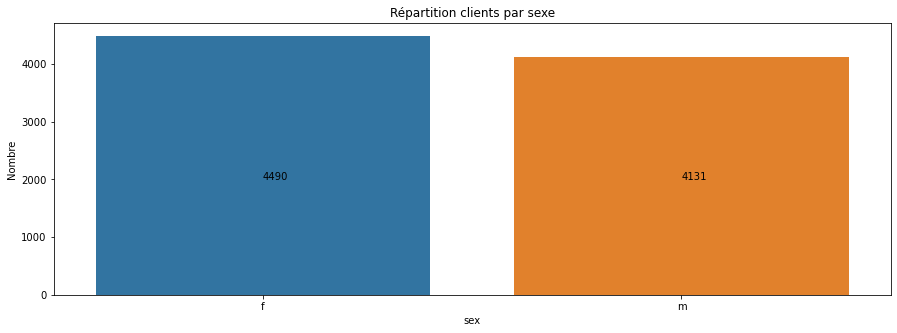

```
% homme dans le fichier client : 47.92%
% femme dans le fichier client : 52.08%
```

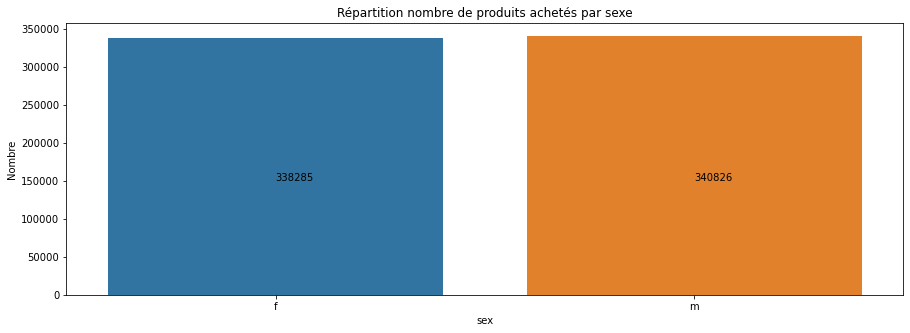

```
% homme dans les transactions : 50.19%
% femme dans les transactions : 49.81%
```

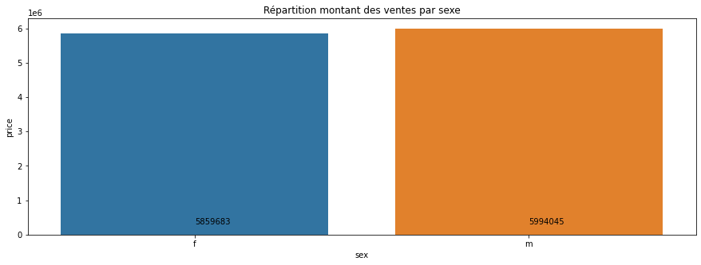

```
% homme dans le CA : 50.57%
% femme dans le CA : 49.43%


Nombre transactions hommes/Nombre hommes :  82.5
Nombre transactions femmes/Nombre femmes :  75.3
CA hommes/Nombre hommes :  163224.1
CA femmes/Nombre femmes :  148969.9
```

```python
#Distribution genre chez les clients
df_memo=df_customers_clean.groupby(['sex']).size().reset_index(name="Nombre")
mem=plt.figure(figsize=(15,5))
mem=sns.barplot(x='sex',y='Nombre',data=df_memo)
memo=plt.text(0,2000,df_memo.iloc[0,1])
memo=plt.text(1,2000,df_memo.iloc[1,1])
mem=plt.title("Répartition clients par sexe")
mem=plt.show()
print("% homme dans le fichier client : {:.2f}%".format(df_memo.iloc[1,1]/df_customers_clean['client_id'].count()*100))
print("% femme dans le fichier client : {:.2f}%".format(df_memo.iloc[0,1]/df_customers_clean['client_id'].count()*100))
nbmen=df_memo.iloc[1,1]
nbwomen=df_memo.iloc[0,1]


#Distribution genre pour le nombre de transactions
df_memo=df.groupby(['sex']).size().reset_index(name="Nombre")
mem=plt.figure(figsize=(15,5))
mem=sns.barplot(x='sex',y='Nombre',data=df_memo)
memo=plt.text(0,150000,format(df_memo.iloc[0,1]))
memo=plt.text(1,150000,df_memo.iloc[1,1])
mem=plt.title("Répartition nombre de produits achetés par sexe")
mem=plt.show()
print("% homme dans les transactions : {:.2f}%".format(df_memo.iloc[1,1]/df['id_prod'].count()*100))
print("% femme dans les transactions : {:.2f}%".format(df_memo.iloc[0,1]/df['id_prod'].count()*100))
nbmennbtrans=df_memo.iloc[1,1]
nbwomennbtrans=df_memo.iloc[0,1]


#Distribution genre pour le montant des ventes

df_memo=df.groupby(['sex']).sum().reset_index()
mem=plt.figure(figsize=(15,5))
mem=sns.barplot(x='sex',y='price',data=df_memo)
memo=plt.text(0,300000,int(df_memo.iloc[0,2]))
memo=plt.text(1,300000,int(df_memo.iloc[1,2]))
mem=plt.title("Répartition montant des ventes par sexe")
mem=plt.show()
print("% homme dans le CA : {:.2f}%".format(int(df_memo.iloc[1,2])/df['price'].sum()*100))
print("% femme dans le CA : {:.2f}%".format(int(df_memo.iloc[0,2])/df['price'].sum()*100))
nbmenca=df_memo.iloc[1,1]
nbwomenca=df_memo.iloc[0,1]

print("\n\nNombre transactions hommes/Nombre hommes : ",round(nbmennbtrans/nbmen,1))
print("Nombre transactions femmes/Nombre femmes : ",round(nbwomennbtrans/nbwomen,1))
print("CA hommes/Nombre hommes : ",round(nbmenca/nbmen,1))
print("CA femmes/Nombre femmes : ",round(nbwomenca/nbwomen,1))
```

Répartition genres clients : il y a plus de femmes que d'hommes parmi les clients (environ 52,1% de femmes contre 47,9% d'hommes).  
Pour le nombre de produits achetés : il y a une égalité quasi parfaite (environ 50,2% d'hommes et 49,8% de femmes).  
Pour la répartition du montant des ventes par genre : les hommes réalisent un peu plus d'achats que les femmes (50,57% d'hommes et 49,43% de femmes).  
En proportion, ce sont les hommes qui achètent le plus de produits et qui génèrent le plus de chiffre d'affaires alors qu'il y a plus de femmes dans le fichier client.

### **Variable quantitative 'age'**

**==> Calculs mesures de dispersion et de forme**

```python
#Analyse descriptive de la variable 'Age'
#Moyenne, médiane, mode, minimum, maximum, Variance, Ecart type, Skewness,Kurtosis
print("Moyenne d'âge = ",round(df_customers_clean['Age'].mean(), 2),"ans")
print("Médiane des âges = ",round(df_customers_clean['Age'].median(), 2),"ans")
print("Mode des âge = ",df_customers_clean['Age'].mode()[0],"€")
print("Age minimum = ",df_customers_clean['Age'].min(),"ans")
print("Age maximum = ",df_customers_clean['Age'].max(),"ans")
print("Variance des âges = ",round(df_customers_clean['Age'].var(ddof=0),2),"ans")
print("Ecart type des âges = ",round(df_customers_clean['Age'].std(ddof=0),2),"ans")
print("Skewness = ",round(df_customers_clean['Age'].skew(),2))
print("Kurtosis = ",round(df_customers_clean['Age'].kurt(),2))
```

```
Moyenne d'âge =  43.72 ans
Médiane des âges =  43.0 ans
Mode des âge =  18 €
Age minimum =  18 ans
Age maximum =  93 ans
Variance des âges =  286.18 ans
Ecart type des âges =  16.92 ans
Skewness =  0.36
Kurtosis =  -0.64
```

**==>Analyse de la distribution de la variable âge chez les clients**

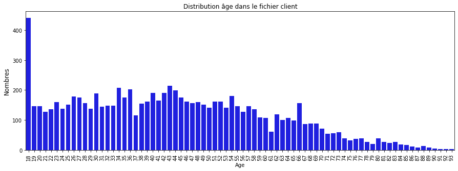

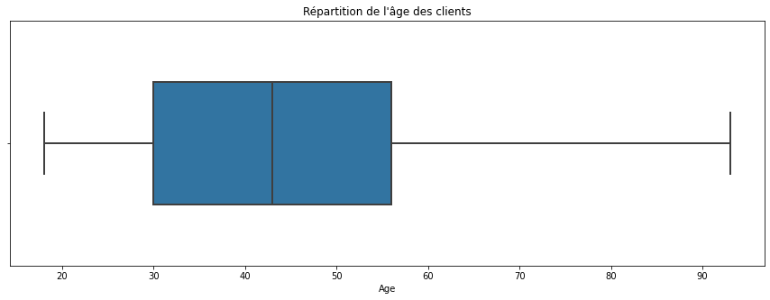

```python
#Via un diagramme bâton
df1=df_customers_clean.copy()
df2=df1.groupby(['Age']).count().reset_index()
mem=sns.barplot(x='Age',y='birth',data=df2,color='blue')
mem=plt.title("Distribution âge dans le fichier client")
mem=plt.ylabel('Nombres', fontsize=12)
memo=plt.xticks(rotation=90)
memo=plt.show()

#Via un boxplot
memo=sns.boxplot(x='Age', data=df_customers_clean, width = 0.5, linewidth = 2,orient='h')
memo=plt.xlabel('Age')
memo=plt.title('Répartition de l\'âge des clients')
memo=plt.show()

Q1=df_customers_clean['Age'].quantile(0.25)
Q2=df_customers_clean['Age'].quantile(0.5)
Q3=df_customers_clean['Age'].quantile(0.75)
IQ=Q3-Q1
MAX=Q3+1.5*IQ
MIN=Q1-1.5*IQ
IQdroite=Q3-Q2
IQgauche=Q2-Q1
```

L'âge des clients va de 18 ans à 93 ans.  
C'est chez les 18 ans qu'on rencontre le plus de clients(des étudiants).  
75% des personnes ont moins de 56 ans  
50% des personnes ont entre 30 ans et 56 ans

**==>Distribution de la variable "Age" dans les transactions**

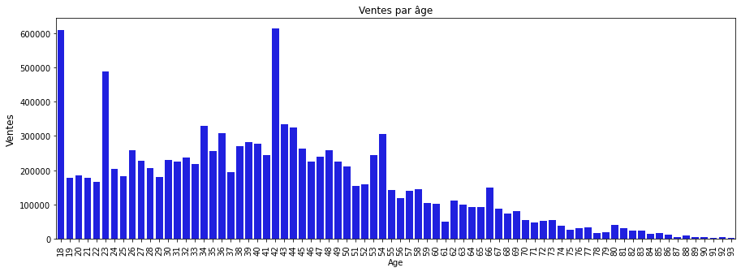

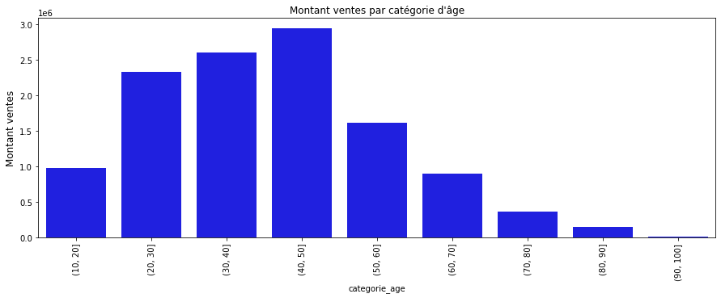

```python
#Distribution des âges  dans les ventes
df1=df.copy()
df2=df1.groupby(['Age']).sum().reset_index()
mem=sns.barplot(x='Age',y='price',data=df2,color='blue')
mem=plt.title("Ventes par âge")
mem=plt.ylabel('Ventes', fontsize=12)
memo=plt.xticks(rotation=90)
mem=plt.show()

#Distribution de classes d'âges  dans les ventes
df1=df.copy()
#Discrétisation de la variable âge (découpage en 9 catégories)
df1['categorie_age']=pd.cut(df1['Age'],bins=[10,20,30,40,50,60,70,80,90,100])
#Affichage graphique
df2=df1.groupby(['categorie_age']).sum().reset_index()
mem=sns.barplot(x='categorie_age',y='price',data=df2,color='blue')
mem=plt.title("Montant ventes par catégorie d'âge")
mem=plt.ylabel('Montant ventes', fontsize=12)
memo=plt.xticks(rotation=90)
mem=plt.show()
```

On constate un pic de consommation à 18ans, 23 ans et entre 40 et 42 ans.

**==> Répartition du CA entre clients**

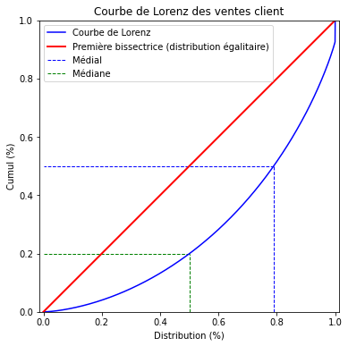

```
Indice de Gini : 0.45
```

```python
#Courbe de Lorenz répartition achats entre les clients
#Constitution du dataframe de regroupement par id_client
df1=df.copy()
df_cli=df1.groupby(['client_id']).sum().reset_index()
graphic.lorenz_gini(df_cli['price'],"Courbe de Lorenz des ventes client",0.79,0.2)
```

La répartition du CA par client est inégalitaire :  
* 50% des clients réalisent 20% des ventes.  
* 21% des clients réalisent 50% des ventes  
Cette inégalité est confirmée par l'indice de Gini qui est à 0.45.  
A noter une répartition totalement inégalitaire pour environ 1% des clients qui représentent moins de 10% du CA (en haut à droite, courbe parallèle à l'axe des ordonnées)

**==>Top 10 des clients ayant passé le plus de commandes**

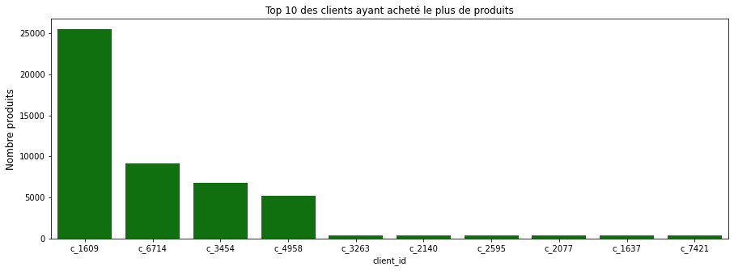

|  | client_id | sex | Age | id_prod |
| --- | --- | --- | --- | --- |
| 0 | c_1609 | m | 42 | 25488 |
| 1 | c_6714 | f | 54 | 9181 |
| 2 | c_3454 | m | 53 | 6770 |
| 3 | c_4958 | m | 23 | 5195 |
| 4 | c_3263 | f | 37 | 403 |
| 5 | c_2140 | f | 45 | 402 |
| 6 | c_2595 | m | 48 | 398 |
| 7 | c_2077 | f | 38 | 384 |
| 8 | c_1637 | f | 34 | 380 |
| 9 | c_7421 | m | 44 | 379 |

```python
#Top clientèle ayant passé le plus de commandes

df_top_clients=df.groupby(['client_id','sex','Age']).count().sort_values(by='session_id',ascending=False).reset_index()
df_top_clients10=df_top_clients.head(10)

mem=plt.figure(figsize=(15,5))
mem=sns.barplot(x='client_id',y='session_id',data=df_top_clients10,color='green')
mem=plt.title("Top 10 des clients ayant acheté le plus de produits")
mem=plt.ylabel('Nombre produits', fontsize=12)
mem=plt.show()
df_top_clients10.iloc[:,0:4]
```

On constate que 4 clients sortent du lot. Ces personnes sont des professionnels. Ce sont des outliers pour notre étude.  
On supprime ces clients de la base d'avoir une meilleure distribution de la variable "Age" et "sex" dans les transactions .

**==>Distribution des âges des clients dans les ventes sans les 4 outliers**

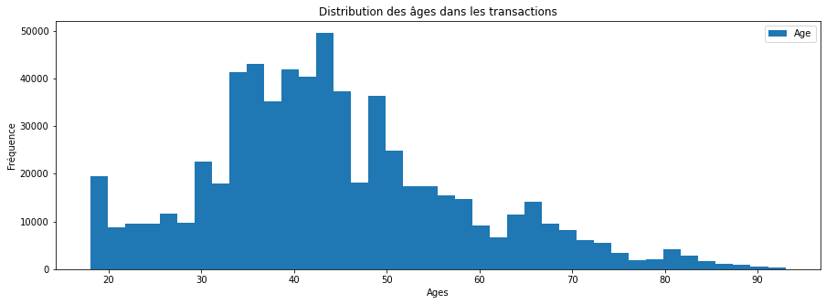

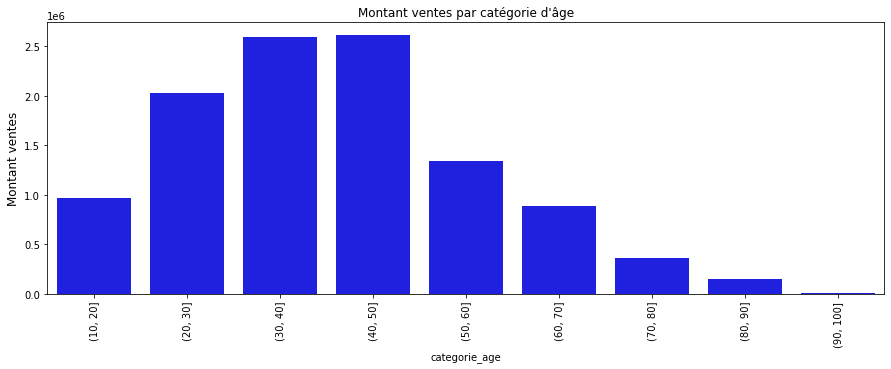

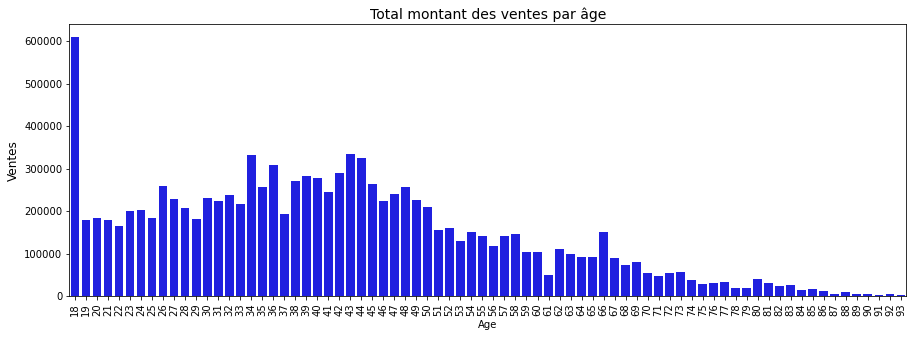

```python
df_corrige=df.copy()
df_corrige=df_corrige.loc[(df_corrige['client_id']!='c_1609')&(df_corrige['client_id']!='c_6714')&\
                          (df_corrige['client_id']!='c_3454')&(df_corrige['client_id']!='c_4958')]

#Distribution des âges  dans les transactions
memo=plt.xlabel('Ages')
memo=plt.ylabel('Fréquence')
mem=plt.title("Distribution des âges dans les transactions")
memo=plt.hist(df_corrige.loc[~df_corrige['Age'].isna()]['Age'], bins=40,label='Age')
memo=plt.legend(loc='best')
memo=plt.show()

df1=df_corrige.copy()
#discrétisation de la variable âge (découpage en 9 catégories)
df1['categorie_age']=pd.cut(df1['Age'],bins=[10,20,30,40,50,60,70,80,90,100])
#affichage graphique
df2=df1.groupby(['categorie_age']).sum().reset_index()
mem=sns.barplot(x='categorie_age',y='price',data=df2,color='blue')
mem=plt.title("Montant ventes par catégorie d'âge")
mem=plt.ylabel('Montant ventes', fontsize=12)
memo=plt.xticks(rotation=90)
mem=plt.show()


#Distribution des âges  dans les ventes
df1=df_corrige.copy()
df2=df1.groupby(['Age']).sum().reset_index()
mem=sns.barplot(x='Age',y='price',data=df2,color='blue')
mem=plt.title("Total montant des ventes par âge", fontsize=14)
mem=plt.ylabel('Ventes', fontsize=12)
memo=plt.xticks(rotation=90)
```

Ceux qui passent le plus de commandes : les clients entre 42 et 44 ans  
Ceux qui génèrent le plus de chiffre d'affaires : les clients de 18 ans (des étudiants)  
Par catégorie d'âge : ceux qui génèrent le plus de chiffres : les 30/50 ans puis les - de 30 ans.

**==>Distribution du genre client dans les ventes sans les 4 outliers**

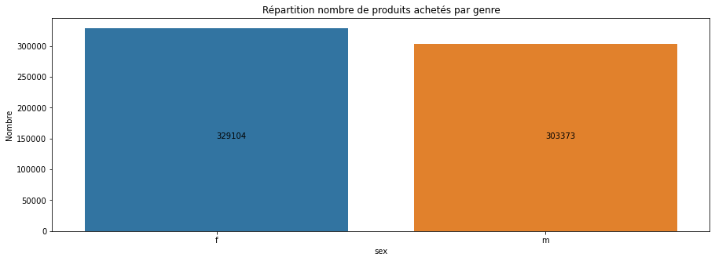

```
% homme dans les transactions : 47.97%
% femme dans les transactions : 52.03%
```

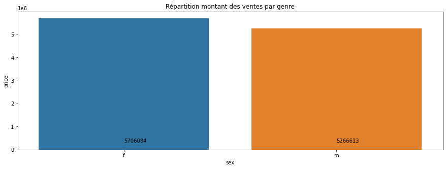

```
% homme dans le CA : 48.00%
% femme dans le CA : 52.00%


Nombre transactions hommes/Nombre hommes :  73.4
Nombre transactions femmes/Nombre femmes :  73.3
CA hommes/Nombre hommes :  145266.9
CA femmes/Nombre femmes :  144945.8
```

```python
#Distribution genre client pour le nombre de transactions
df_memo=df_corrige.groupby(['sex']).size().reset_index(name="Nombre")
mem=plt.figure(figsize=(15,5))
mem=sns.barplot(x='sex',y='Nombre',data=df_memo)
memo=plt.text(0,150000,format(df_memo.iloc[0,1]))
memo=plt.text(1,150000,df_memo.iloc[1,1])
mem=plt.title("Répartition nombre de produits achetés par genre")
mem=plt.show()
print("% homme dans les transactions : {:.2f}%".format(df_memo.iloc[1,1]/df_corrige['id_prod'].count()*100))
print("% femme dans les transactions : {:.2f}%".format(df_memo.iloc[0,1]/df_corrige['id_prod'].count()*100))
nbmennbtrans=df_memo.iloc[1,1]
nbwomennbtrans=df_memo.iloc[0,1]


#Distribution genre client pour le montant des ventes
df_memo=df_corrige.groupby(['sex']).sum().reset_index()
mem=plt.figure(figsize=(15,5))
mem=sns.barplot(x='sex',y='price',data=df_memo)
memo=plt.text(0,300000,int(df_memo.iloc[0,2]))
memo=plt.text(1,300000,int(df_memo.iloc[1,2]))
mem=plt.title("Répartition montant des ventes par genre")
mem=plt.show()
print("% homme dans le CA : {:.2f}%".format(int(df_memo.iloc[1,2])/df_corrige['price'].sum()*100))
print("% femme dans le CA : {:.2f}%".format(int(df_memo.iloc[0,2])/df_corrige['price'].sum()*100))
nbmenca=df_memo.iloc[1,1]
nbwomenca=df_memo.iloc[0,1]

print("\n\nNombre transactions hommes/Nombre hommes : ",round(nbmennbtrans/nbmen,1))
print("Nombre transactions femmes/Nombre femmes : ",round(nbwomennbtrans/nbwomen,1))
print("CA hommes/Nombre hommes : ",round(nbmenca/nbmen,1))
print("CA femmes/Nombre femmes : ",round(nbwomenca/nbwomen,1))
```

Pour le nombre de produits achetés : la part de femmes qui achètent des livres > part des hommes (47,96% d'hommes contre 52,03% de femmes).  
Pour la répartition du montant des ventes par sexe : la part des femmes > part des hommes (47,99% d'hommes contre 52% de femmes).  
Le ratio "Nombre transactions par genre/Nombre d'individu par genre" est quasiment identique quel que soit le sexe : les hommes et les femmes réalisent quasiment le même nombre de transactions. Il en est de même pour le ratio "Chiffre d'affaires par genre / Nombre d'individu par genre".

**==>Les plus gros acheteurs par catégorie**

```python
#Categorie dans lesquels les groupes achètent le +
df1=df_corrige.copy()
df1['categorie_age']=pd.cut(df1['Age'],bins=[10,20,30,40,50,60,70,80,90,100])
df2=df1.groupby(['categorie_age','categ']).count().reset_index()
print("\nTop catégorie 0")
df_cat0=df2.loc[df2['categ']==0][['categorie_age','id_prod']]
df_cat0[df_cat0['id_prod']==df_cat0['id_prod'].max()]
print("\nTop catégorie 1")
df_cat1=df2.loc[df2['categ']==1][['categorie_age','id_prod']]
df_cat1[df_cat1['id_prod']==df_cat1['id_prod'].max()]
print("\nTop catégorie 2")
df_cat2=df2.loc[df2['categ']==2][['categorie_age','id_prod']]
df_cat2[df_cat2['id_prod']==df_cat2['id_prod'].max()]
```

```
Top catégorie 0
```

|  | categorie_age | id_prod |
| --- | --- | --- |
| 9 | (40, 50] | 149892 |

```
Top catégorie 1
```

|  | categorie_age | id_prod |
| --- | --- | --- |
| 10 | (40, 50] | 46798 |

```
Top catégorie 2
```

|  | categorie_age | id_prod |
| --- | --- | --- |
| 5 | (20, 30] | 20238 |

**==> Répartition du CA entre clients sans les outliers**

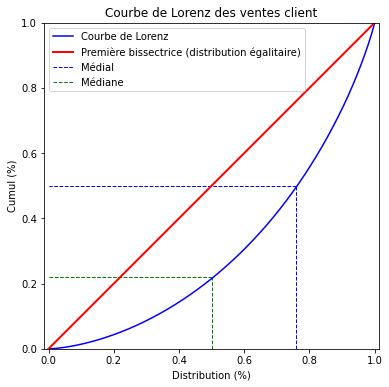

```
Indice de Gini : 0.4
```

```python
#Courbe de Lorenz répartition achats entre les clients
#Constitution du dataframe de regroupement par id_client
df1=df_corrige.copy()
df_cli=df1.groupby(['client_id']).sum().reset_index()
graphic.lorenz_gini(df_cli['price'],"Courbe de Lorenz des ventes client",0.76,0.22)
```

Naturellement, la répartition du CA par client est moins inégalitaire : 24% des clients réalisent 50% des ventes alors que 50% des clients réalisent 22% des ventes.  
L'indice de Gini est plus faible (0.4).

**==> Analyse des 4 clients professionnels**

```
Total achats professionnels : 881030.54
Montant CA c_1609 : 324033.35
Montant CA c_3454 : 113637.93
Montant CA c_4958 : 289760.34
Montant CA c_6714 : 153598.92
% du CA total :  7.43
```

|  | client_id | sex | birth | Age |
| --- | --- | --- | --- | --- |
| 1378 | c_4958 | m | 1999 | 23 |
| 1911 | c_6714 | f | 1968 | 54 |
| 3641 | c_1609 | m | 1980 | 42 |
| 8087 | c_3454 | m | 1969 | 53 |

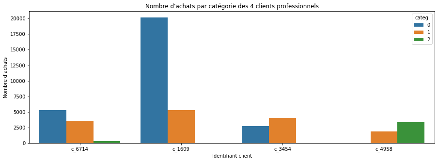

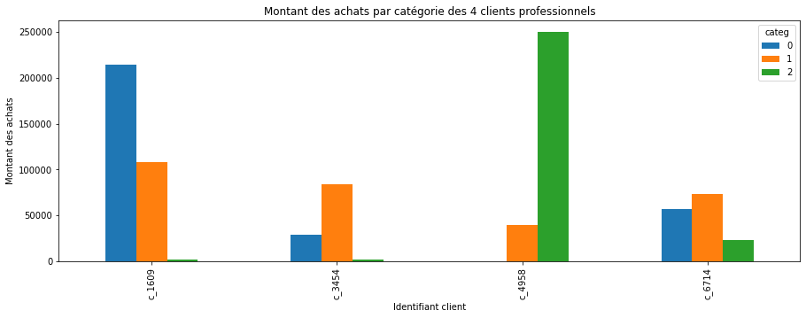

```python
#Création d'un dataframe avec les 4 clients professionnels
df_pro=df.reset_index().copy()
df_pro=df_pro.loc[(df_pro['client_id']=='c_1609')|(df_pro['client_id']=='c_6714')|\
                          (df_pro['client_id']=='c_3454')|(df_pro['client_id']=='c_4958')]

print("Total achats professionnels :",round(df_pro['price'].sum(),2))
print("Montant CA c_1609 :",round(df_pro.loc[df_pro['client_id']=='c_1609']['price'].sum(),2))
print("Montant CA c_3454 :",round(df_pro.loc[df_pro['client_id']=='c_3454']['price'].sum(),2))
print("Montant CA c_4958 :",round(df_pro.loc[df_pro['client_id']=='c_4958']['price'].sum(),2))
print("Montant CA c_6714 :",round(df_pro.loc[df_pro['client_id']=='c_6714']['price'].sum(),2))

print("% du CA total : ",round(df_pro['price'].sum()/df['price'].sum()*100,2))

df_customers_clean.loc[(df_customers_clean['client_id']=='c_1609')|(df_customers_clean['client_id']=='c_6714')|\
                          (df_customers_clean['client_id']=='c_3454')|(df_customers_clean['client_id']=='c_4958')]

#Nombre d'achats par client et par catégorie
memo=sns.countplot(data=df_pro, x='client_id', hue='categ')
memo=plt.title("Nombre d'achats par catégorie des 4 clients professionnels")
memo=plt.xlabel("Identifiant client")
memo=plt.ylabel("Nombre d'achats")
memo=plt.show()

#Montant des ventes par clients et par catégorie
df_pro1=df_pro.pivot_table(index='client_id', columns='categ', values='price', aggfunc=sum).reset_index()
memo=df_pro1.plot(kind='bar', x='client_id')
memo=plt.title("Montant des achats par catégorie des 4 clients professionnels")
memo=plt.xlabel("Identifiant client")
memo=plt.ylabel("Montant des achats")
memo=plt.show()
```

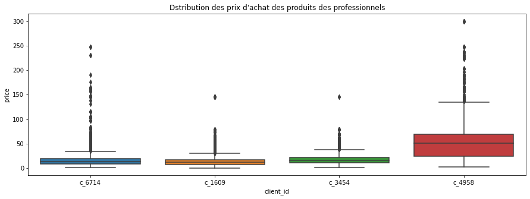

```python
#Affichage des achats par vendeur professionnels
memo=sns.boxplot(data=df_pro, y='price', x='client_id')
memo=plt.title('Dstribution des prix d\'achat des produits des professionnels')
memo=plt.show()
```

Analyse clients professionnels :  
* Celui qui achète le plus dans la catégorie 0: c_1609  
* Celui qui achète le plus dans la catégorie 1: c_1609  
* Celui qui achète le plus dans la catégorie 2: c_4958  
* c_1609, c_3454 et c_6714: ils achètent dans les 3 catégories  
* c_4958 : il n'achète que dans les catégories 1 et 2. C'est celui qui achète les produits les plus chers et qui fait les plus gros achats par catégorie.

Suite du projet : Analyses bivariées